15 - Final exam 第四組  
10773020 李庭溱  
11773028 葛俊余  
11773035 簡柏宇  
11773040 余俊宏  
2022-12-12

```r
library(dplyr)
library(data.table)
library(stringr)
library(scales)
library(ggplot2)
library(ggthemes)
library(ggrepel)
library(colorspace)
library(kableExtra)

data_original <- "20221212_final_exam.csv" %>%
  fread() %>%
  setnames(c("gender", "age", "bp_sys", "bp_dia")) %>%
  data.table() %>%
  mutate(gender = gender %>% factor(., c(0, 1), c("Female", "Male")))

data_analysis = data_original%>%
  melt(c("gender", "age"), variable.name = "var")%>%
  mutate(var = var%>%factor(., c("bp_sys", "bp_dia"), c("Systolic B.P.", "Diastolic B.P.")))
```

# 1 資料說明

現有一個血壓測量的樣本資料包含

- 性別 (SEX: 0=女生、1=男生)
- 年齡
- 收縮壓 (SYSBP，單位：mmHg 毫米汞柱)
- 舒張壓 (DIASBP，單位：mmHg 毫米汞柱)

# 2 以下題目需要以軟體進行操作，不限使用哪一種軟體

## 2.1 請描述收縮壓及舒張壓變項

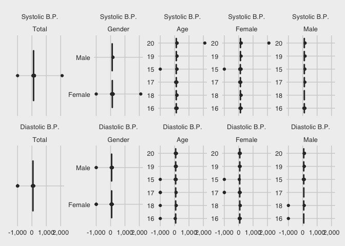

```r
rbind(data_analysis %>% mutate(class = "Total", type = " "),
      data_analysis %>% mutate(class = "Gender", type = gender),
      data_analysis %>% mutate(class = "Age", type = age),
      data_analysis %>% mutate(class = gender, type = age))%>%
  ggplot(aes(x = value, y = type))+
  geom_boxplot()+
  facet_wrap(var~class, scales = "free_y", ncol = 5)+
  scale_x_continuous(labels = comma_format())+
  theme_fivethirtyeight()
```

看起來有超大、超小的異常數值，不可能是人類，先排除

```r
data_original %>%
  filter(bp_sys > 200 | bp_sys < 0 | bp_dia > 200 | bp_dia < 0) %>%
  kable(escape = F, col.names = c("Gender", "Age", "Systolic B.P.", "Diastolic B.P."),
        align = "llrr")%>%
  kable_styling(full_width = F, c("hover", "striped", "condensed"))
```

| Gender | Age | Systolic B.P. | Diastolic B.P. |
| --- | --- | --- | --- |
| Female | 15 | 110 | -999 |
| Female | 20 | 2100 | 110 |
| Female | 17 | 130 | -999 |
| Female | 15 | -999 | 80 |
| Female | 17 | 70 | -999 |
| Female | 17 | 92 | -999 |
| Male | 18 | 108 | -999 |
| Male | 16 | 80 | -999 |

收縮壓與舒張壓在不同人群的分佈如下所示

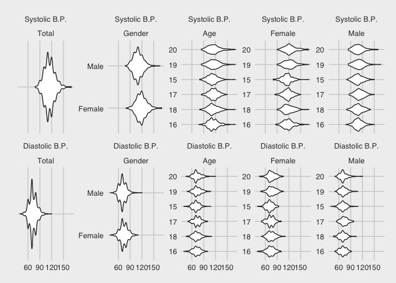

```r
data_analysis = data_original%>%
  filter(!(bp_sys > 200 | bp_sys < 0 | bp_dia > 200 | bp_dia < 0)) %>%
  melt(c("gender", "age"), variable.name = "var")%>%
  mutate(var = var%>%factor(., c("bp_sys", "bp_dia"), c("Systolic B.P.", "Diastolic B.P.")))

rbind(
  data_analysis %>% mutate(class = "Total", type = " "),
  data_analysis %>% mutate(class = "Gender", type = gender),
  data_analysis %>% mutate(class = "Age", type = age),
  data_analysis %>% mutate(class = gender, type = age)
) %>%
  ggplot(aes(x = value, y = type)) +
  geom_violin() +
  facet_wrap(var ~ class, scales = "free_y", ncol = 5) +
  scale_x_continuous(labels = comma_format()) +
  theme_fivethirtyeight()
```

收縮壓與舒張壓在不同人群的描述性統計指標如下所示

```r
f_summary <- function(x) {
  x %>%
    group_by(class, type, var) %>%
    summarise(
      n = n(),
      mean = value %>% mean(na.rm = T),
      sd = value %>% sd(na.rm = T),
      min = value%>%min(na.rm=T),
      q1 = value %>% quantile(probs = .25, na.rm = T),
      q2 = value %>% quantile(probs = .50, na.rm = T),
      q3 = value %>% quantile(probs = .75, na.rm = T),
      max = value%>%max(na.rm=T)
    )%>%
    data.table
}

rbind(data_analysis %>% mutate(class = "Total", type = " ") %>% f_summary(),
      data_analysis %>% mutate(class = "Gender", type = gender) %>% f_summary(),
      data_analysis %>% mutate(class = "Age", type = age) %>% f_summary(),
      data_analysis %>% mutate(class = gender, type = age) %>% f_summary())%>%
  dcast(class + type ~ var,
        value.var = c("n", "mean", "sd", "min", "q1", "q2", "q3", "max"))%>%
  select(class, type,
         `n_Systolic B.P.`, `mean_Systolic B.P.`, `sd_Systolic B.P.`,
         `min_Systolic B.P.`, `q1_Systolic B.P.`, `q2_Systolic B.P.`, `q3_Systolic B.P.`, `max_Systolic B.P.`,
         `n_Diastolic B.P.`, `mean_Diastolic B.P.`, `sd_Diastolic B.P.`,
         `min_Diastolic B.P.`, `q1_Diastolic B.P.`, `q2_Diastolic B.P.`, `q3_Diastolic B.P.`, `max_Diastolic B.P.`)%>%
  mutate(class = class%>%
           factor(., c("Total", "Gender", "Age", "Female", "Male")))%>%
  mutate_if(is.numeric, ~comma(., 1))%>%
  arrange(class, type)%>%
  kable(escape = F, col.names = c("Char.", "Type",
                      "Sample<br>size", "Mean", "SD",
                      "Min", "25th", "50th", "75th", "Max",
                      "Sample<br>size", "Mean", "SD",
                      "Min", "25th", "50th", "75th", "Max"),
        align = "llrrrrrrrrrrrrrrrr")%>%
  collapse_rows(c(1))%>%
  kable_styling(full_width = F, c("hover", "striped", "condensed"))%>%
  add_header_above(c(" "=2, "Systolic" = 8, "Diastolic" = 8))
```

| Char. | Type | Systolic Sample size | Systolic Mean | Systolic SD | Systolic Min | Systolic 25th | Systolic 50th | Systolic 75th | Systolic Max | Diastolic Sample size | Diastolic Mean | Diastolic SD | Diastolic Min | Diastolic 25th | Diastolic 50th | Diastolic 75th | Diastolic Max |
| --- | --- | --- | --- | --- | --- | --- | --- | --- | --- | --- | --- | --- | --- | --- | --- | --- | --- |
| Total |  | 1,902 | 115 | 14 | 78 | 106 | 112 | 122 | 170 | 1,902 | 73 | 10 | 40 | 68 | 70 | 80 | 120 |
| Gender | Female | 959 | 119 | 14 | 80 | 110 | 120 | 128 | 170 | 959 | 74 | 10 | 40 | 68 | 74 | 80 | 110 |
|  | Male | 943 | 110 | 13 | 78 | 100 | 110 | 120 | 166 | 943 | 71 | 10 | 40 | 65 | 70 | 78 | 120 |
| Age | 15 | 323 | 112 | 13 | 80 | 104 | 110 | 120 | 170 | 323 | 71 | 9 | 40 | 64 | 70 | 76 | 108 |
|  | 16 | 349 | 114 | 13 | 78 | 106 | 112 | 120 | 170 | 349 | 72 | 10 | 40 | 66 | 70 | 80 | 100 |
|  | 17 | 316 | 115 | 12 | 84 | 108 | 116 | 122 | 150 | 316 | 74 | 10 | 50 | 70 | 73 | 80 | 100 |
|  | 18 | 320 | 114 | 14 | 80 | 105 | 110 | 122 | 170 | 320 | 73 | 10 | 46 | 66 | 70 | 80 | 110 |
|  | 19 | 311 | 116 | 15 | 84 | 106 | 116 | 126 | 170 | 311 | 74 | 10 | 48 | 68 | 72 | 80 | 108 |
|  | 20 | 283 | 116 | 16 | 84 | 104 | 114 | 122 | 170 | 283 | 74 | 11 | 45 | 68 | 70 | 80 | 120 |
| Female | 15 | 176 | 115 | 13 | 80 | 108 | 114 | 120 | 170 | 176 | 71 | 9 | 40 | 64 | 70 | 78 | 94 |
|  | 16 | 179 | 118 | 14 | 86 | 110 | 120 | 126 | 170 | 179 | 73 | 11 | 40 | 68 | 74 | 80 | 100 |
|  | 17 | 180 | 117 | 12 | 84 | 110 | 118 | 124 | 150 | 180 | 73 | 10 | 50 | 70 | 72 | 80 | 100 |
|  | 18 | 157 | 119 | 14 | 90 | 110 | 118 | 130 | 170 | 157 | 75 | 11 | 50 | 68 | 75 | 80 | 110 |
|  | 19 | 147 | 121 | 14 | 90 | 110 | 120 | 130 | 170 | 147 | 77 | 11 | 48 | 70 | 76 | 84 | 106 |
|  | 20 | 120 | 123 | 16 | 90 | 114 | 120 | 130 | 170 | 120 | 76 | 11 | 45 | 70 | 74 | 82 | 106 |
| Male | 15 | 147 | 109 | 12 | 80 | 100 | 110 | 118 | 150 | 147 | 70 | 10 | 40 | 64 | 70 | 76 | 108 |
|  | 16 | 170 | 110 | 11 | 78 | 102 | 110 | 118 | 150 | 170 | 70 | 9 | 50 | 64 | 70 | 78 | 92 |
|  | 17 | 136 | 113 | 12 | 86 | 104 | 111 | 120 | 150 | 136 | 74 | 9 | 54 | 68 | 74 | 80 | 98 |
|  | 18 | 163 | 109 | 12 | 80 | 100 | 110 | 117 | 140 | 163 | 70 | 9 | 46 | 64 | 70 | 76 | 104 |
|  | 19 | 164 | 111 | 13 | 84 | 100 | 110 | 120 | 166 | 164 | 72 | 9 | 50 | 66 | 70 | 78 | 108 |
|  | 20 | 163 | 110 | 14 | 84 | 100 | 110 | 120 | 160 | 163 | 72 | 11 | 50 | 66 | 70 | 78 | 120 |

## 2.2 您是否會使用全部樣本進行分析，或是設定條件納入或排除某些樣本

不會，如上表，共排除 8 筆數據

## 2.3 請想辦法利用上述高血壓判斷標準，定義高血壓分期

```r
data_analysis_2 = data_original%>%
  filter(!(bp_sys > 200 | bp_sys < 0 | bp_dia > 200 | bp_dia < 0)) %>%
  mutate(ht_stage = "",
         ht_stage = ifelse(bp_sys>=160 | bp_dia>=100, "H.T. Stage 2", ht_stage),
         ht_stage = ifelse(ht_stage=="" &(bp_sys>=140 | bp_dia>=90), "H.T. Stage 1", ht_stage),
         ht_stage = ifelse(ht_stage=="" &(bp_sys>=120 | bp_dia>=80), "Elevated", ifelse(ht_stage=="", "Normal", ht_stage)),
         ht_stage = ht_stage%>%factor(., c("Normal", "Elevated", "H.T. Stage 1", "H.T. Stage 2")))

data_analysis_2%>%
  group_by(ht_stage)%>%
  summarise(n=n())%>%
  kable(col.names = c("H.T. stage", "Sample size"))%>%
  kable_styling(full_width = F, c("hover", "striped", "condensed"))
```

| H.T. stage | Sample size |
| --- | --- |
| Normal | 982 |
| Elevated | 726 |
| H.T. Stage 1 | 161 |
| H.T. Stage 2 | 33 |

## 2.4 請用適當的圖說明有高血壓的人數占比

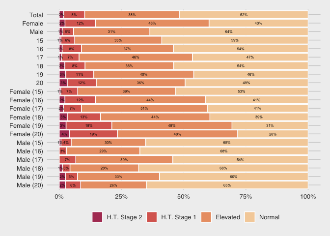

```r
f_summary_2 = function(x){
  x%>%
    group_by(class, type, ht_stage)%>%
    summarise(n = n())%>%
    ungroup%>%
    group_by(class, type)%>%
    mutate(rate = n /sum(n))%>%
    data.table
}

rbind(
  data_analysis_2 %>% mutate(class = "Total", type = "Total")%>%f_summary_2,
  data_analysis_2 %>% mutate(class = "Gender", type = gender)%>%f_summary_2,
  data_analysis_2 %>% mutate(class = "Age", type = age)%>%f_summary_2,
  data_analysis_2 %>% mutate(class = gender, type = paste(gender, " (", age, ")", sep = ""))%>%f_summary_2
) %>%
  ggplot(aes(x = rate, y = type%>%forcats::fct_rev(), fill = ht_stage)) +
  geom_col(color = "white", position = position_stack())+
  geom_text(aes(label = percent(rate,1)), size = 2, position = position_stack(vjust = .5))+
  scale_x_continuous(labels = percent_format())+
  scale_fill_discrete_sequential("RedOr", breaks = c("Normal", "Elevated", "H.T. Stage 1", "H.T. Stage 2")%>%rev)+
  theme_fivethirtyeight()+
  theme(legend.position = "bottom",
        legend.title = element_blank())
```

## 2.5 請問血壓是否正常與性別有無統計相關

檢定高血壓（stage 1, 2）的風險因子

在單因子模型中，年齡較高者、女性，均 H.T. 的風險因子

加入年齡與性別的多因子模型中亦相同，其 OR 分別為 1.02 [1.01 - 1.03]、0.91 [0.89, 0.94]

表示年齡每增加一歲，高血壓風險則增加 2%，男性高血壓的風險較女性少 9%

考量不同性別年齡對高血壓盛行率可能有差異，將性別進行分層研究年齡對高血壓的影響

假設高血壓、性別、年齡三者間沒有其他複雜因素

則年齡對高血壓的平均因果效應為 1.03 與 1.01 之平均 1.02，也就是每增加一歲高血壓風險則增加 2%

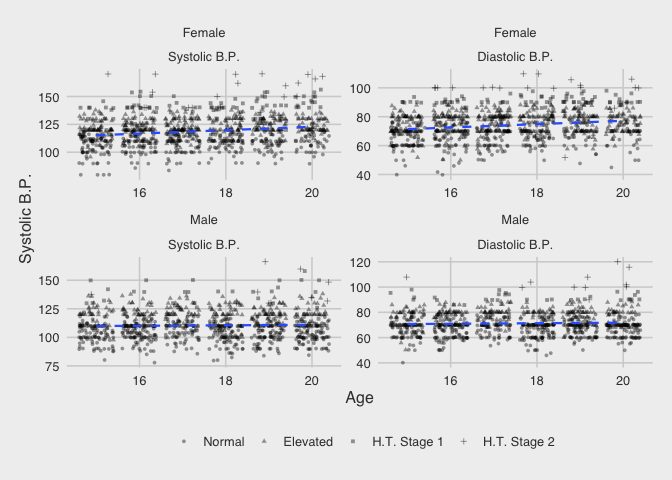

```r
data_analysis_2%>%
  melt(id.vars = c("gender", "age", "ht_stage"))%>%
  mutate(variable = variable%>%factor(., c("bp_sys", "bp_dia"), c("Systolic B.P.", "Diastolic B.P.")))%>%
  ggplot(aes(x = age, y = value))+
  geom_jitter(aes(shape = ht_stage), alpha = .4, size = 1)+
  geom_smooth(se = F, method = "lm", linetype = 2, size = .8)+
  scale_x_continuous(labels = comma_format())+
  scale_color_discrete_diverging("Blue Red 2", breaks = c("Female", "Male"), rev=T)+
  facet_wrap(gender ~ variable, ncol = 2, scale = "free")+
  labs(x = "Age", y = "Systolic B.P.")+
  theme_fivethirtyeight()+
  theme(legend.position = "bottom",
        legend.title = element_blank(),
        axis.title = element_text())
```

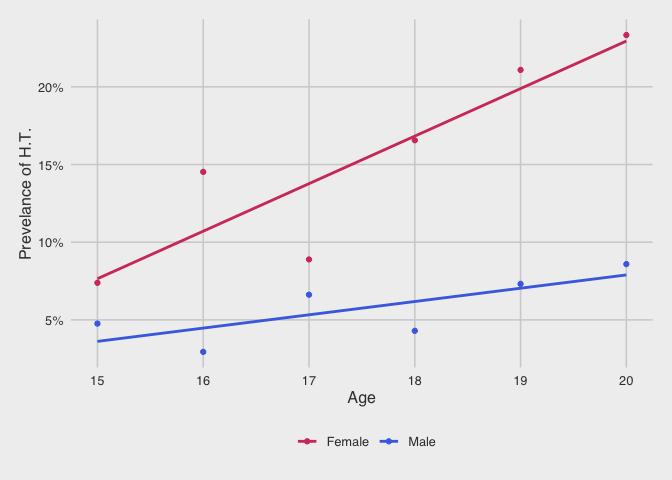

```r
data_analysis_2%>%
  group_by(gender, age)%>%
  summarise(value = (ht_stage%in%c("H.T. Stage 1", "H.T. Stage 2"))%>%sum / n())%>%
  ggplot(aes(x = age, y = value, color = gender))+
  geom_point()+
  geom_smooth(se = F, method = "lm")+
  scale_x_continuous(labels = comma_format())+
  scale_y_continuous(labels = percent_format())+
  scale_color_discrete_diverging("Blue Red 2", breaks = c("Female", "Male"), rev=T)+
  labs(x = "Age", y = "Prevelance of H.T.")+
  theme_fivethirtyeight()+
  theme(legend.position = "bottom",
        legend.title = element_blank(),
        axis.title = element_text())
```

```r
data_analysis_2 = data_analysis_2%>% mutate( y = ht_stage %in% c("H.T. Stage 1", "H.T. Stage 2"))

model_1 = data_analysis_2%>%glm(data =., y~age)

model_2 = data_analysis_2%>%glm(data =., y~gender)

model_3 = data_analysis_2%>%glm(data =., y~age + gender)

model_4 = data_analysis_2%>%filter(gender == "Female")%>%glm(data =., y~age)

model_5 = data_analysis_2%>%filter(gender == "Male")%>%glm(data =., y~age)

jtools::export_summs(model_1, model_2, model_3, model_4, model_5,
                     error_format = "[{conf.low}, {conf.high}]",
                     model.names = c("Age", "Gender", "Age + Gender", "Age, Female", "Age, Female"),
                     exp = TRUE)
```

[output not shown]

# 3 以下題目為計算題，可以手寫、使用軟體等各種方式回答

## 3.1 一名男生的收縮壓是 140 mmHg、舒張壓是 100 mmHg，請問他的收縮壓與舒張壓分別超過多少百分比的男性？

- 收縮壓低於 140 mmHg 男性有 97.67%
- 舒張壓低於 100 mmHg 男性有 98.94%

```r
data_analysis_2%>%
  filter(gender == "Male")%>%
  summarise(sys_140 = (bp_sys<140)%>%sum/n(),
            dia_100 = (bp_dia<100)%>%sum/n())%>%
  ungroup%>%
  mutate_if(is.numeric, ~percent(., 0.01))%>%
  kable(col.names = c("收縮壓 < 140 的男性", "舒張壓 < 100 的男性"), align = "r")%>%
  kable_styling(full_width = F, c("hover", "striped", "condensed"))
```

| 收縮壓 < 140 的男性 | 舒張壓 < 100 的男性 |
| --- | --- |
| 97.67% | 98.94% |

## 3.2 假設想知道血壓正常的機率是多少，請問此樣本對於母體血壓正常的機率點估計是多少？請計算95%信賴區間

- 52% [49% - 54%]

```r
data_analysis_2%>%
  summarise(n = n(),
            normal = (ht_stage == "Normal")%>%sum,
            rate = prop.test(x=982, n=1902, conf.level=.95)$estimate,
            rate_upper = prop.test(x=982, n=1902, conf.level=.95)$conf.int[1],
            rate_lower = prop.test(x=982, n=1902, conf.level=.95)$conf.int[2])%>%
  mutate_at(.vars = c(1:2), ~comma(.,1))%>%
  mutate_at(.vars = c(3:5), ~percent(.,1))%>%
  kable(col.names = c("樣本人數", "正常血壓人數", "正常血壓佔比", "Lower limit", "Upper limit"), align = "r")%>%
  kable_styling(full_width = F, c("hover", "striped", "condensed"))
```

| 樣本人數 | 正常血壓人數 | 正常血壓佔比 | Lower limit | Upper limit |
| --- | --- | --- | --- | --- |
| 1,902 | 982 | 52% | 49% | 54% |

## 3.3 女生有第一期或第二期高血壓的機率是多少

```r
data_analysis_2%>%
  filter(gender == "Female")%>%
  summarise(n = n(),
            normal = (ht_stage %in%c("H.T. Stage 1", "H.T. Stage 2") )%>%sum,
            rate = prop.test(x=982, n=1902, conf.level=.95)$estimate,
            rate_upper = prop.test(x=982, n=1902, conf.level=.95)$conf.int[1],
            rate_lower = prop.test(x=982, n=1902, conf.level=.95)$conf.int[2])%>%
  mutate_at(.vars = c(1:2), ~comma(.,1))%>%
  mutate_at(.vars = c(3:5), ~percent(.,1))%>%
  kable(col.names = c("女性樣本人數", "女性高血壓 1 2 期人數", "女性高血壓 1 2 期人數佔比", "Lower limit", "Upper limit"), align = "r")%>%
  kable_styling(full_width = F, c("hover", "striped", "condensed"))
```

[output not shown]

## 3.4 假設血壓是否正常服從二項式分布，請問超過10%人數有高血壓的機率是多少

- 60.1%

```r
percent(1 - pbinom(round(data_analysis_2%>%nrow()*0.1), data_analysis_2%>%nrow(), data_analysis_2$ht_stage%in%c("H.T. Stage 1", "H.T. Stage 2")%>%sum / data_analysis_2%>%nrow()), .1)
```

```
## [1] "60.1%"
```